# ggplot2 for publication + outreach - part 2

Ryssa Moffat

Last update: 03 October, 2025

# Set up

## Loading packages

```r
knitr::opts_chunk$set(echo = TRUE)
#install.packages("pacman")
pacman::p_load(here, dplyr, ggplot2, ggpubr, viridis, ggh4x, stringr,
               forcats, tidyr)
```

```r
# Ryssa's go-to theme
theme_set(theme_light()+
            theme(
              plot.title = element_text(size=rel(1.2),face="bold"),
              axis.title = element_text(size=rel(1),face="bold"),
              axis.text = element_text(size=rel(1),colour = 'black'),
              strip.text = element_text(size=rel(1),colour = 'black',
                                        face = "bold"),
              legend.text = element_text(size=rel(1)),
              legend.title = element_text(size=rel(1),face="bold"),
              panel.grid = element_blank()))
```

## Data sets

### Robots

We invited kids (5-12 years) to read to different social robots. Afterward, we asked them to rate the robot on a couple attributes.

[Caruana et al. (2022). Perceptions of intelligence & sentience shape children’s interactions with robot reading companions](https://www.nature.com/articles/s41598-023-32104-7).

- `id` participant identifier
- `chosen`which robot the child chose (NAO, Cozmo, MiRo)
- `Enjoy_R` ratings of enjoyment of reading with chosen robot (1-3)
- `Helpful_R` ratings of how helpful chosen robot was during reading (1-3)
- `GoodListener_R` ratings of how chosen robot listened to child reading (1-3)
- `GoodTeacher_R` ratings of chosen robot’s skill as teacher (1-3)
- `Kind_R` ratings of chosen robot’s kindness (1-3)

```r
robot_ratings <- read.csv(here::here("data/robot_ratings.csv")) %>%
  select(-X)

# _R shows it's a rating
# child-friendly ratings scale included: 1 = 'a little bit', 2 = 'somewhere in the middle', 3 = 'a lot'
head(robot_ratings)
```

```
##     id chosen Enjoy_R Helpful_R GoodListener_R GoodTeacher_R Kind_R
## 1 P101    NAO       2         2              1             1      2
## 2 P102  Cozmo       2         2              2             1      2
## 3 P103   MiRo       3         3              3             1      3
## 4 P104  Cozmo       3         2              3             2      3
## 5 P105    NAO       2         2              3             2      2
## 6 P106  Cozmo       3         3              3             2      3
```

# 1. Same units = same plot

Let’s plot the mean and SD for each rating for each robot.

## Spatially inefficient

Make separate plots and join them up using `ggarrange`. Starting with mean ratings of enjoyment:

```r
# get mean value for top of bar plot and sd for error bars in new df
enjoyment_mean <- robot_ratings %>%
  group_by(chosen) %>%
  summarise(mean = mean(Enjoy_R,na.rm=FALSE),
            std = sd(Enjoy_R, na.rm=FALSE))

head(enjoyment_mean)
```

```
## # A tibble: 3 × 3
##   chosen  mean   std
##   <chr>  <dbl> <dbl>
## 1 Cozmo   2.73 0.467
## 2 MiRo    3    0
## 3 NAO     2.73 0.594
```

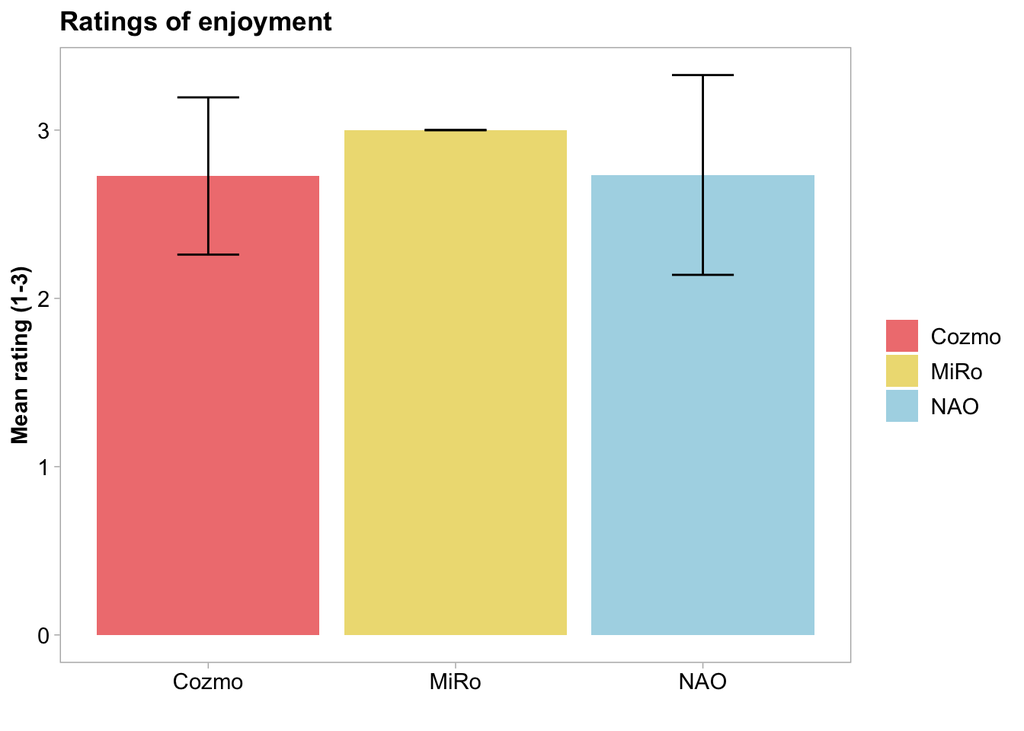

```r
enjoyment <- enjoyment_mean %>%
  ggplot(aes(x=chosen, y=mean, fill=chosen))+
  geom_bar(stat = "identity", position="dodge")+
  geom_errorbar(aes(ymin=mean-std, ymax=mean+std, group=chosen),
                colour="black", width = 0.25, position=position_dodge(width = 0.9))+
  labs(title = "Ratings of enjoyment", x="", y="Mean rating (1-3)")+
  scale_fill_manual(values=c("lightcoral","lightgoldenrod","lightblue"))+
  guides(fill=guide_legend(title=""))

enjoyment
```

Now ratings of helpfulness:

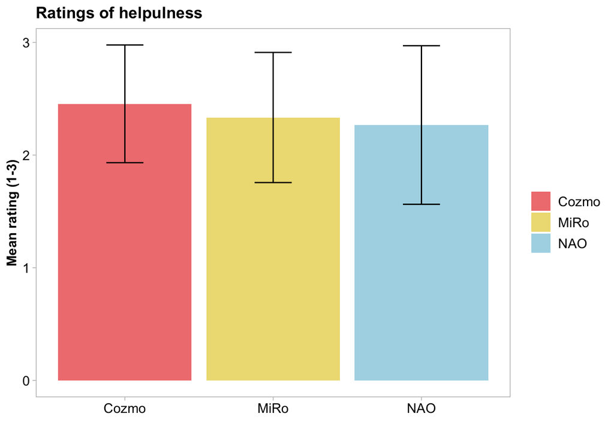

```r
# get mean value for top of bar plot and sd for error bars in new df
helpful_mean <- robot_ratings %>%
  group_by(chosen) %>%
  summarise(mean = mean(Helpful_R,na.rm=FALSE),
            std = sd(Helpful_R, na.rm=FALSE))

helpful <- helpful_mean %>%
  ggplot(aes(x=chosen, y=mean, fill=chosen))+
  geom_bar(stat = "identity", position="dodge")+
  geom_errorbar(aes(ymin=mean-std, ymax=mean+std, group=chosen),
                colour="black", width = 0.25, position=position_dodge(width = 0.9))+
  labs(title = "Ratings of helpulness", x="", y="Mean rating (1-3)")+
  scale_fill_manual(values=c("lightcoral","lightgoldenrod","lightblue"))+
  guides(fill=guide_legend(title=""))

helpful
```

Now joining them up:

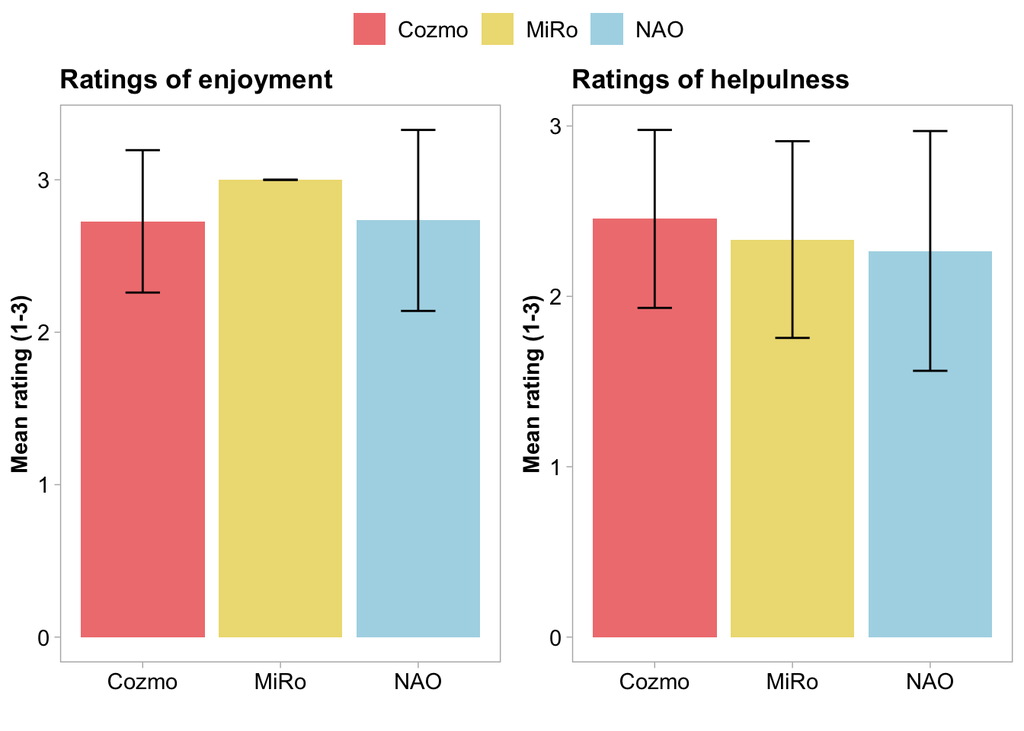

```r
# plot both
ggarrange(enjoyment, helpful, common.legend = TRUE)
```

## More efficient

To be able to plot the ratings more efficiently, the ratings values all need to be in one columne (instead of separate columns).

```r
# get all ratings in one column
rating_long <- robot_ratings %>%
  pivot_longer(cols = ends_with("_R"),
               names_to = "question",
               values_to = "value")

rating_long <- rating_long %>%
  mutate(questionName = str_sub(question,,-3)) #remove _R to improve labels

head(rating_long)
```

```
## # A tibble: 6 × 5
##   id    chosen question       value questionName
##   <chr> <chr>  <chr>          <int> <chr>
## 1 P101  NAO    Enjoy_R            2 Enjoy
## 2 P101  NAO    Helpful_R          2 Helpful
## 3 P101  NAO    GoodListener_R     1 GoodListener
## 4 P101  NAO    GoodTeacher_R      1 GoodTeacher
## 5 P101  NAO    Kind_R             2 Kind
## 6 P102  Cozmo  Enjoy_R            2 Enjoy
```

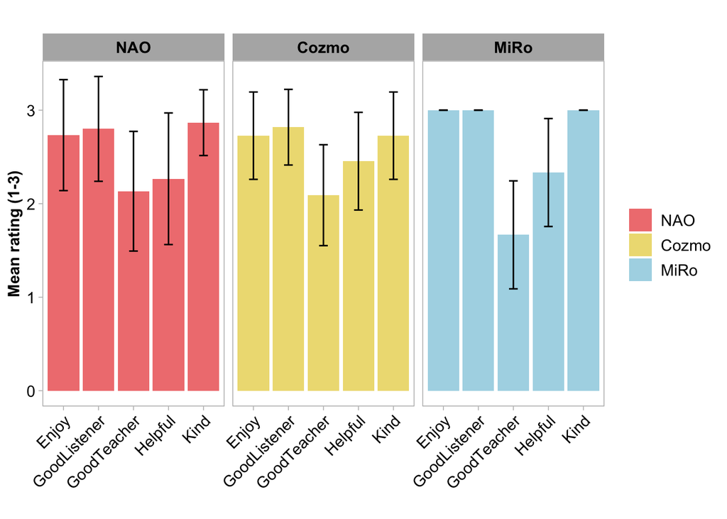

```r
# get mean value for top of bar plot and sd for error bars in new df for all columns
rating_mean <- rating_long %>%
  group_by(chosen, questionName) %>%
  summarise(mean = mean(value,na.rm=FALSE),
            std = sd(value,na.rm=FALSE)) %>%
    mutate(chosen = factor(chosen, levels=c("NAO","Cozmo","MiRo")))# robot order
rating_mean %>%
  ggplot(aes(x=questionName, y=mean, fill=chosen))+
  geom_bar(stat = "identity", position="dodge")+
  geom_errorbar(aes(ymin=mean-std, ymax=mean+std, group=chosen),
                colour="black", width = 0.25,
                position=position_dodge(width = 0.9))+
  labs(title = "", x="", y="Mean rating (1-3)")+
  scale_fill_manual(values=c("lightcoral","lightgoldenrod","lightblue"))+
  guides(fill=guide_legend(title=""))+
  facet_grid(.~chosen)+
  guides(color = "none")+
  theme(axis.text.x = element_text(angle = 45, hjust = 1))
```

```r
  # + coord_flip() # try switching the x and y axis
```

## Spatially efficient

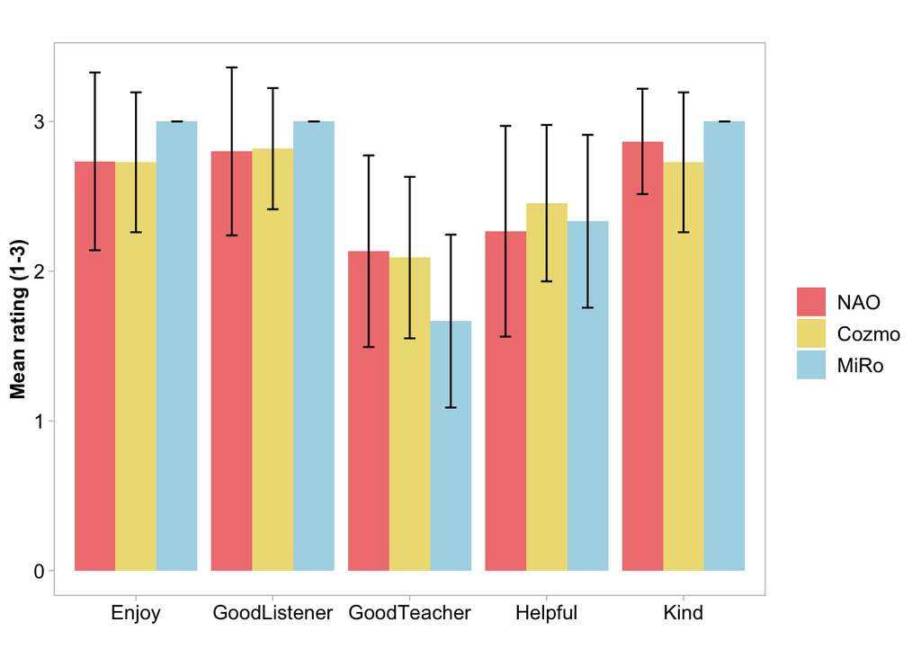

```r
rating_mean %>%
  ggplot(aes(x=questionName, y=mean, fill=chosen))+
  geom_bar(stat = "identity", position="dodge")+
  geom_errorbar(aes(ymin=mean-std, ymax=mean+std, group=chosen),
                colour="black", width = 0.25, position=position_dodge(width = 0.9))+
  labs(title = "", x="", y="Mean rating (1-3)")+
  scale_fill_manual(values=c("lightcoral","lightgoldenrod","lightblue"))+
  guides(fill=guide_legend(title=""))
```

## Efficient + fancy

```r
rating_mean <- rating_mean %>%
  mutate(questionName =case_when(questionName == "GoodTeacher" ~ "Good\nTeacher",
                                  questionName == "GoodListener" ~ "Good\nListener",
                                 TRUE ~ questionName))
head(rating_mean)
```

```
## # A tibble: 6 × 4
## # Groups:   chosen [2]
##   chosen questionName      mean   std
##   <fct>  <chr>            <dbl> <dbl>
## 1 Cozmo  "Enjoy"           2.73 0.467
## 2 Cozmo  "Good\nListener"  2.82 0.405
## 3 Cozmo  "Good\nTeacher"   2.09 0.539
## 4 Cozmo  "Helpful"         2.45 0.522
## 5 Cozmo  "Kind"            2.73 0.467
## 6 MiRo   "Enjoy"           3    0
```

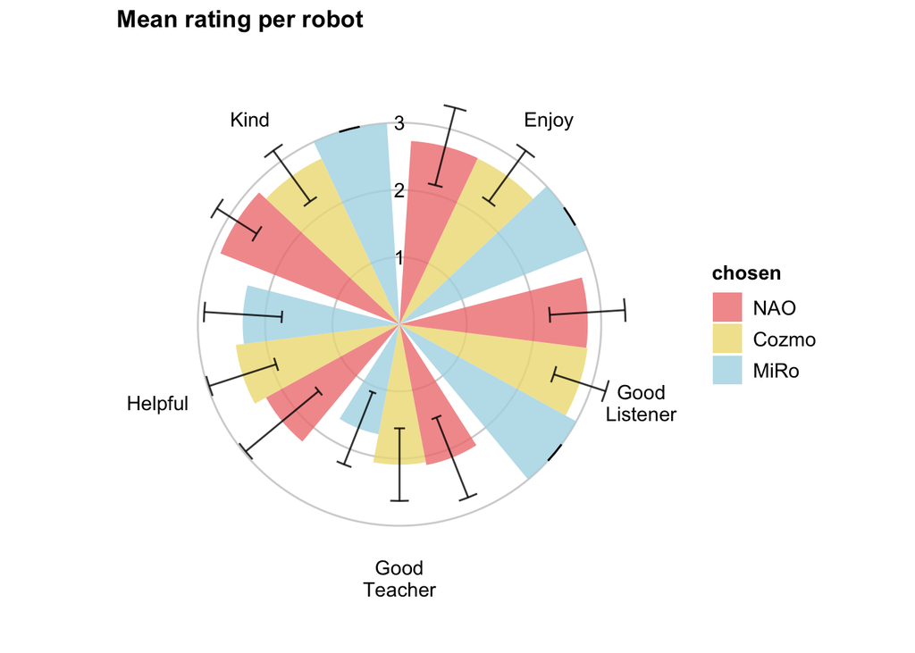

```r
radar_robots <- ggplot(data = rating_mean)+
  geom_hline(aes(yintercept = y), data.frame(y = c(1,2,3)), color = "lightgrey")+
  geom_bar(aes(x=questionName, y=mean, fill=chosen),
           alpha = 0.8, stat = "identity", position="dodge")+
  geom_errorbar(aes(x=questionName,ymin=mean-std, ymax=mean+std, group=chosen),
                colour="black", width = 0.25, alpha = 0.8,
                position=position_dodge(0.9))+
  scale_fill_manual(values=c("lightcoral","lightgoldenrod","lightblue"))+
  labs(title = "Mean rating per robot", x= "", y = "")+
  coord_polar()+
  theme(panel.border = element_blank(),
        axis.text.y = element_blank(),
        axis.ticks.y = element_blank())

radar_robots +
    annotate(x = .5, y = 3, label = "3", geom = "text")+
    annotate(x = .5, y = 2, label = "2", geom = "text")+
    annotate(x = .5, y = 1, label = "1", geom = "text")
```

## All together

Heat maps are surprisingly efficient. Whenever there seem to be too many variables to plot at once, but they have are in the same units, try a heat map (or two).

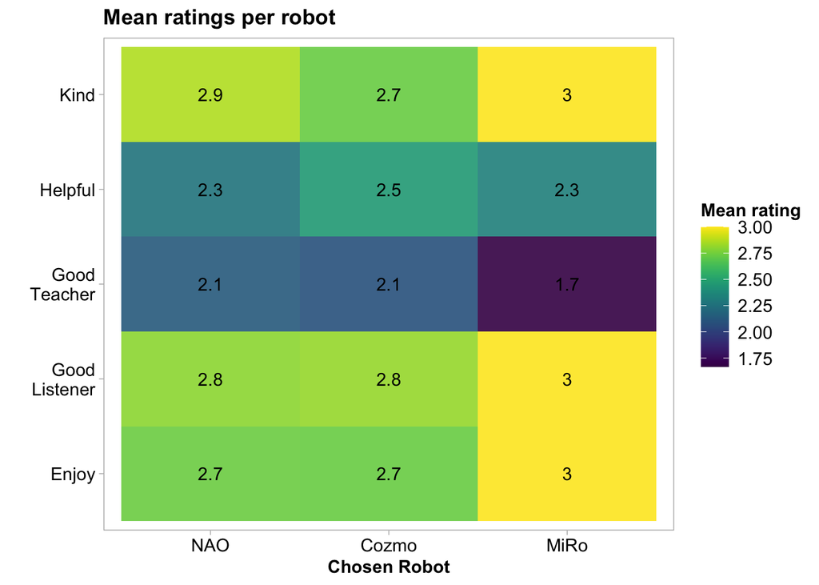

```r
# heatmaps
rating_mean %>%
  ggplot(aes(x=chosen, y=questionName, fill = mean))+
  geom_tile(alpha = 0.9)+
  geom_text(aes(label = round(mean, 1))) +
  scale_fill_viridis() +
  labs(title = "Mean ratings per robot", x="Chosen Robot", y="",
       fill = "Mean rating")
```